# Cultural Data Science - Exam Project

Health Behaviour in School-aged Children

Laura Wulff Paaby (202006161) & Rikke Uldbæk (202007501)

08 January, 2023

## Loading Packages

```r
#loading packages
pacman::p_load(ggplot2, tidyverse, lmerTest, stats)
```

## Loading Data

The data must be downloaded from Digital Exam and loaded in the chunk below. Please fill out your own working directory where the data is stored on your device. We kindly ask you to delete the data after the assessment of this exam.

```r
#set your working directory:
#setwd()

# Load the HBSC.csv here:
hbsc2014 <-  read.csv("HBSC_2014.csv")
```

## Data Preprocessing

In this section, appropriate filtering and pre-processing of the data will be carried out.

### Countries of Interest

The countries of interest in this paper are: Denmark, Italy, Spain, England, Latvia. In the hbsc2014 dataframe, all countries are denoted with a country-number, however this is rather confusing, thus we rename the country-number in accordance with the actual country-name (Denmark = 208000, Italy = 380000, Spain = 724000, England = 826001, Latvia = 428000)

```r
# Filtering the five countries
dat2014 <- hbsc2014 %>%
   filter(COUNTRYno == 208000 | COUNTRYno == 380000 | COUNTRYno == 724000 | COUNTRYno == 826001 | COUNTRYno == 428000 ) %>%
  rename(countryno = COUNTRYno,
         surveyyear = year,
         uniqueid = UniqueID) # renaming it to match the others

# a little data was collected in 2013, this is renamed to 2014 for further analysis
dat2014$surveyyear <- ifelse(dat2014$surveyyear== 2013, 2014, 2014)# making all data from 2013 into 2014
```

Apparently England had some data from 2013 as the only country, we changed this data to being 2014

```r
# renaming countries in a function
rename_func <- function(data){
data$country_name <- (ifelse(data$countryno == "208000","Denmark", ifelse(data$countryno == "380000", "Italy", ifelse(data$countryno == "724000","Spain", ifelse(data$countryno == "826001","England", ifelse(data$countryno == "428000","Latvia", ifelse(data$countryno == "80400", "Ukraine", NA)))))))
return(data)
}

#using the function and checking data
# dat2014
dat2014 <- rename_func(dat2014)
unique(dat2014$country_name)
```

```
## [1] "Denmark" "Italy"   "Latvia"  "Spain"   "England"
```

### Further Subsetting

First we will subset the data of interest for model building.

```r
#Check we only have data from 2014
unique(hbsc2014$HBSC)
```

```
## [1] 2014
```

```r
#subset the important variables
subset_df2014 <- dat2014 %>%
  select(uniqueid,AGE,sex, #general variables
         lifesat,#mental health variable
         breakfastwd, breakfastwe, fruits, toothbr,sweets, vegetables, ondiet# nutritional variables
         )
```

### Replace NAs

Then we will identify and replace NA’s with the mean

```r
#Replace NA's with mean (note makes everything numeric)
subset_df2014[subset_df2014==-99] <- NA #some rows may contain -99 instead of NA (replace then)
subset_df2014[subset_df2014=="NaN"] <- NA #some rows may contain NaN instead of NA (replace then)

subset_df2014 <- subset_df2014 %>%
  mutate_if(is.numeric, ~replace_na(.,mean(., na.rm = TRUE))) %>%
  round(digits = 0)
```

Finally country-name is added to the dataframe since it disturbed previous work by being a character class

```r
#Adding country to the dataframe
subset_df2014 <- cbind(subset_df2014, country= dat2014$country_name)

#making country a factor
subset_df2014$country <- as.factor(subset_df2014$country)
```

### Plotting Countries

```
## No summary function supplied, defaulting to `mean_se()`
```

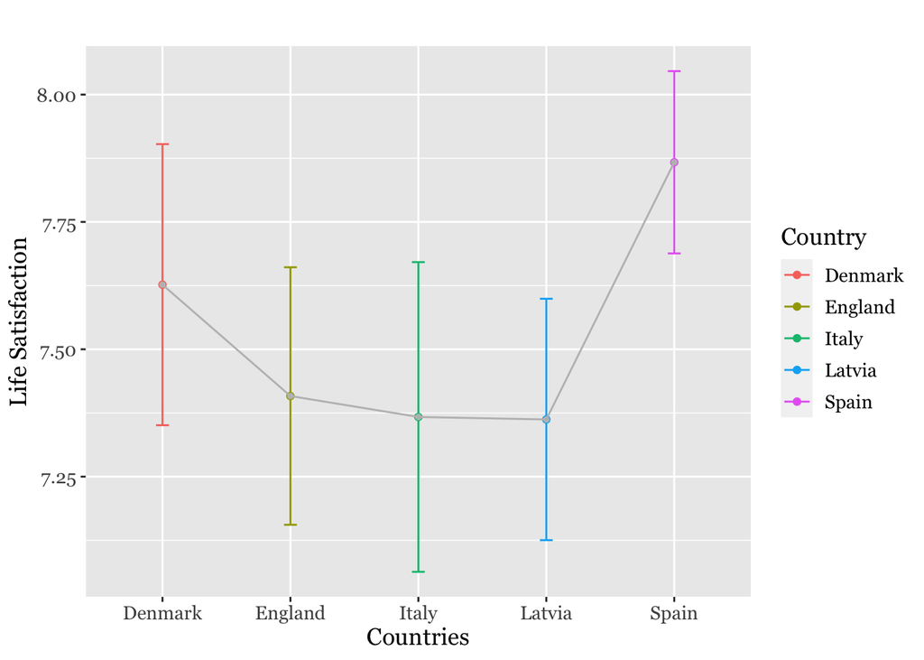

```r
country_plot<- ggplot(subset_df2014, aes(x= country, y=lifesat, colour =country)) + geom_point(stat="summary", fun.y="mean") +
  geom_errorbar(aes(width = 0.1), stat="summary", fun.data="mean_se", fun.args = list(mult = 10))+ggtitle("")+
  stat_summary(fun.y=mean, aes(group=1), geom="line", colour="grey") +
  stat_summary(fun.y=mean, aes(group=1), geom="point", colour="grey", size=1)+
  labs(x = "Countries", y = "Life Satisfaction") + theme(text=element_text(size=13, family="Georgia"))
#rename legend
update_labels(country_plot, list(colour="Country"))
```

## Analysis

In this section we will model nutritional factors and mental health in order to investigate their relationship.

### Models

Various of models are constructed to model nutritional factors on mental health in order to find the best fitting model.

```r
## mental health ~ nutritional factors

#####country as random intercept
MH_m1 <- lmer(lifesat ~ breakfastwd + (1 | country), subset_df2014)
MH_m2 <- lmer(lifesat ~ breakfastwd+ breakfastwe+ (1 | country), subset_df2014)
MH_m3 <- lmer(lifesat ~ breakfastwd+ breakfastwe+ fruits+ (1 | country), subset_df2014)
MH_m4 <- lmer(lifesat ~ breakfastwd+ breakfastwe+ fruits+ ondiet +(1 | country), subset_df2014)
MH_m5 <- lmer(lifesat ~ breakfastwd+ breakfastwe+ fruits+ ondiet + sweets + (1 | country), subset_df2014)
MH_m6 <- lmer(lifesat ~ breakfastwd+ breakfastwe+ fruits+ ondiet + sweets + vegetables + (1 | country), subset_df2014)


######country as fixed effects
MH_m7 <- lm(lifesat ~ breakfastwd + country, subset_df2014)
MH_m8 <- lm(lifesat ~ breakfastwd+ breakfastwe+ country, subset_df2014)
MH_m9 <- lm(lifesat ~ breakfastwd+ breakfastwe+ fruits+ country, subset_df2014)
MH_m10 <- lm(lifesat ~ breakfastwd+ breakfastwe+ fruits+ ondiet +country, subset_df2014)
MH_m11 <- lm(lifesat ~ breakfastwd+ breakfastwe+ fruits+ ondiet + sweets + country, subset_df2014)
MH_m12 <- lm(lifesat ~ breakfastwd+ breakfastwe+ fruits+ ondiet + sweets + vegetables + country, subset_df2014)

######interactions
MH_m13 <- lm(lifesat ~ fruits:vegetables + country, subset_df2014)
MH_m14 <- lm(lifesat ~ ondiet:vegetables + country, subset_df2014)
MH_m15 <- lm(lifesat ~ sweets:vegetables + country, subset_df2014)
MH_m16 <- lm(lifesat ~ breakfastwd:vegetables + country, subset_df2014)
MH_m17 <- lm(lifesat ~ breakfastwe:vegetables + country, subset_df2014)
MH_m18 <- lm(lifesat ~ ondiet:fruits + country, subset_df2014)
MH_m19 <- lm(lifesat ~ ondiet:sweets + country, subset_df2014)
MH_m20 <- lm(lifesat ~ ondiet:breakfastwd + country, subset_df2014)
MH_m21 <- lm(lifesat ~ ondiet:breakfastwe + country, subset_df2014)
MH_m22 <- lm(lifesat ~ sweets:fruits + country, subset_df2014)
MH_m23 <- lm(lifesat ~ sweets:breakfastwd + country, subset_df2014)
MH_m24 <- lm(lifesat ~ sweets:breakfastwe + country, subset_df2014)
MH_m25 <- lm(lifesat ~ breakfastwd:fruits + country, subset_df2014)
MH_m26 <- lm(lifesat ~ breakfastwe:fruits + country, subset_df2014)
MH_m27 <- lm(lifesat ~ breakfastwd:breakfastwe + country, subset_df2014)
MH_m28 <- lm(lifesat ~  country:sweets, subset_df2014)
MH_m29 <- lm(lifesat ~  country:fruits, subset_df2014)
MH_m30 <- lm(lifesat ~  country:vegetables, subset_df2014)
MH_m31 <- lm(lifesat ~  country:ondiet, subset_df2014)
MH_m32 <- lm(lifesat ~  country:breakfastwd, subset_df2014)
MH_m33 <- lm(lifesat ~  country:breakfastwe, subset_df2014)
```

### Model Comparison

In this section we will compare the best fitting models by evaluating AIC and BIC.

```r
#writing AIC values down
MH_aic <- AIC(MH_m1, MH_m2,MH_m3, MH_m4, MH_m5, MH_m6, MH_m7, MH_m8,MH_m9,MH_m10, MH_m11, MH_m12, MH_m13, MH_m14, MH_m15, MH_m16, MH_m17, MH_m18, MH_m19, MH_m20, MH_m21, MH_m22, MH_m23, MH_m24, MH_m25, MH_m26, MH_m27, MH_m28, MH_m29, MH_m30, MH_m31, MH_m32, MH_m33)


#writing down BIC values
MH_bic <- BIC(MH_m1, MH_m2,MH_m3, MH_m4, MH_m5, MH_m6, MH_m7, MH_m8,MH_m9,MH_m10, MH_m11, MH_m12, MH_m13, MH_m14, MH_m15, MH_m16, MH_m17, MH_m18, MH_m19, MH_m20, MH_m21, MH_m22, MH_m23, MH_m24, MH_m25, MH_m26, MH_m27, MH_m28, MH_m29, MH_m30, MH_m31, MH_m32, MH_m33)


#putting results into one dataframe:
MH_df <- tibble(Model = c("MH_m1", "MH_m2","MH_m3", "MH_m4", "MH_m5", "MH_m6", "MH_m7", "MH_m8","MH_m9","MH_m10", "MH_m11", "MH_m12", "MH_m13", "MH_m14", "MH_m15", "MH_m16", "MH_m17", "MH_m18", "MH_m19", "MH_m20", "MH_m21", "MH_m22", "MH_m23", "MH_m24", "MH_m25", "MH_m26", "MH_m27", "MH_m28", "MH_m29", "MH_m30", "MH_m31", "MH_m32", "MH_m33"), BIC=MH_bic$BIC, AIC=MH_aic$AIC)
```

```r
head(MH_df[order(MH_df$BIC, decreasing= F),], n = 3) #best models
```

| Model | BIC | AIC |
| --- | --- | --- |
| MH_m12 | 120043.8 | 119944.1 |
| MH_m11 | 120058.9 | 119967.5 |
| MH_m6 | 120085.8 | 120011.0 |

The model that performs the best is Model 12 (MH_m12) with a BIC = 120043.8 and AIC = 119944.1, and Model 11 (MH_m11) with a BIC = 120058.9 and AIC = 119967.5. However, Model 6 (MH_m6) makes conceptually better sense as we account for baseline-differences in life satisfaction of each country, and thus takes more variability in to account. The conceptually better Model 6 (MH_m6), does only perform minimally worse than Model 12 with a BIC= 120085.8 and AIC = 120011.0.

## Results

### Results of the Model

```r
#printing summary of the model
summary(MH_m6)
```

```
## Linear mixed model fit by REML. t-tests use Satterthwaite's method [
## lmerModLmerTest]
## Formula: lifesat ~ breakfastwd + breakfastwe + fruits + ondiet + sweets +
##     vegetables + (1 | country)
##    Data: subset_df2014
##
## REML criterion at convergence: 119993
##
## Scaled residuals:
##     Min      1Q  Median      3Q     Max
## -4.8372 -0.4790  0.1189  0.6779  2.3048
##
## Random effects:
##  Groups   Name        Variance Std.Dev.
##  country  (Intercept) 0.02734  0.1654
##  Residual             3.19320  1.7870
## Number of obs: 29991, groups:  country, 5
##
## Fixed effects:
##               Estimate Std. Error         df t value Pr(>|t|)
## (Intercept)  6.135e+00  1.054e-01  1.599e+01  58.202  < 2e-16 ***
## breakfastwd  1.079e-01  6.146e-03  2.998e+04  17.550  < 2e-16 ***
## breakfastwe  3.011e-01  2.102e-02  2.997e+04  14.322  < 2e-16 ***
## fruits       9.930e-02  7.150e-03  2.998e+04  13.889  < 2e-16 ***
## ondiet      -2.133e-01  9.239e-03  2.998e+04 -23.083  < 2e-16 ***
## sweets      -4.871e-02  6.902e-03  2.959e+04  -7.057 1.74e-12 ***
## vegetables   3.730e-02  7.430e-03  2.993e+04   5.021 5.18e-07 ***
## ---
## Signif. codes:  0 '***' 0.001 '**' 0.01 '*' 0.05 '.' 0.1 ' ' 1
##
## Correlation of Fixed Effects:
##             (Intr) brkfstwd brekfstw fruits ondiet sweets
## breakfastwd -0.118
## breakfastwe -0.445 -0.293
## fruits      -0.140 -0.058   -0.057
## ondiet      -0.235  0.098    0.055   -0.006
## sweets      -0.296  0.039   -0.015    0.021  0.072
## vegetables  -0.164 -0.040   -0.033   -0.422 -0.035  0.028
```

The summary yields how all fixed effects are significant, however the random effects are not significant. This will be elaborated on in the paper.

### Cross-Country Stats

Calculating mean and standard deviation of life satisfaction for each country

```r
#Denmark
mean(subset_df2014[subset_df2014$country == 'Denmark', 'lifesat'])
```

```
## [1] 7.626831
```

```r
sd(subset_df2014[subset_df2014$country == 'Denmark', 'lifesat'])
```

```
## [1] 1.721045
```

```r
#England
mean(subset_df2014[subset_df2014$country == 'England', 'lifesat'])
```

```
## [1] 7.408247
```

```r
sd(subset_df2014[subset_df2014$country == 'England', 'lifesat'])
```

```
## [1] 1.846004
```

```r
#Italy
mean(subset_df2014[subset_df2014$country == 'Italy', 'lifesat'])
```

```
## [1] 7.367141
```

```r
sd(subset_df2014[subset_df2014$country == 'Italy', 'lifesat'])
```

```
## [1] 1.940032
```

```r
#Latvia
mean(subset_df2014[subset_df2014$country == 'Latvia', 'lifesat'])
```

```
## [1] 7.362246
```

```r
sd(subset_df2014[subset_df2014$country == 'Latvia', 'lifesat'])
```

```
## [1] 1.766305
```

```r
#Spain
mean(subset_df2014[subset_df2014$country == 'Spain', 'lifesat'])
```

```
## [1] 7.867098
```

```r
sd(subset_df2014[subset_df2014$country == 'Spain', 'lifesat'])
```

```
## [1] 1.88824
```